# Kemayaan yang real: *Text mining* pada komentar petisi daring di website change.org

# 1 Data apa?

Data yang digunakan di sini berasal dari laman www.change.org yang didapat dengan metode scrapping. Kata kunci yang digunakan adalah “Gojek.” Dengan metode dan kata kunci tersebut didapat 41 judul petisi dengan distribusi pendukung seperti dapat dilihat pada gambar di bawah ini.

| title | date | jml_pendukung |
| --- | --- | --- |
| JANGAN KEMBALI RENGGUT KEBEBASAN MASYARAKAT JAWA BARAT UNTUK MEMILIH TRANSPORTASI! | 2017-03-10 | 64197 |
| Hentikan Permenhub 108 | 2017-12-28 | 20815 |
| Tolak Pencabutan GoJek Tasikmalaya! | 2017-07-26 | 9643 |
| DUKUNG KEBERADAAN GO-JEK DI PURWOKERTO | 2017-07-14 | 2666 |
| Ijinkan Go-Jek Beroperasi di Wilayah Kabupaten Banyumas | 2017-09-22 | 1714 |
| Kami Membutuhkan Gojek | 2017-03-16 | 1648 |
| Perbaiki Sistem Gojek Yang Merugikan Driver | 2017-06-04 | 1541 |
| Cabut larangan pengoperasian layanan transportasi berbasis online (Gojek, GrabBike,dll) | 2015-12-17 | 1011 |
| Laporkan Sdr. Rian opang jatinangor | 2017-10-03 | 995 |
| Pengelola Apartemen Kalibata City Harus Melindungi Hak Penghuni Atas Akses Transportasi - Gojek dan | 2015-07-20 | 850 |

Selain itu, berdasarkan judul juga diketahui bahwa mayortitas petisi yang dilayangkan untuk mempetisi objek perundangan atau pemerintah (daerah dan pusat). Hal ini dapat dilihat dari daftar terpetisi berikut.

# 2 Siapa yang dipetisi?

| terpetisi | title | inisiator | jml_pendukung |
| --- | --- | --- | --- |
| Joko Widodo, Ahmad Heryawan, Ridwan Kamil, Dedi Taufik Kurohman | JANGAN KEMBALI RENGGUT KEBEBASAN MASYARAKAT JAWA BARAT UNTUK MEMILIH TRANSPORTASI! | Warga Bandung | 64197 |
| PT. GOJEK INDONESIA, PT. Grab Indonesia, Joko Widodo, Budi Karya Sumadi, Menteri Perhubungan | Hentikan Permenhub 108 | Dony Putra Pratama | 20815 |
| Dewan Perwakilan Daerah Kota Tasikmalaya, Budi Budiman | Tolak Pencabutan GoJek Tasikmalaya! | Iwan Fauzi | 9643 |
| Ir. H. Achmad Husein | DUKUNG KEBERADAAN GO-JEK DI PURWOKERTO | Muhamad Prasetyo | 2666 |
| Bupati Banyumas, Kepala Dinas Perhubungan Kabupaten Banyumas, GO-JEK Indonesia | Ijinkan Go-Jek Beroperasi di Wilayah Kabupaten Banyumas | Pendukung adanya GoJek Satria | 1714 |
| Joko Widodo, Hari Prihatno, FX Hadi Rudyatmo | Kami Membutuhkan Gojek | Sidji Pinilih | 1648 |
| Nadiem karim, gojek, PT Gojek Indonesia | Perbaiki Sistem Gojek Yang Merugikan Driver | Adven Kris | 1541 |
| Menteri Perhubungan Ignasius Jonan | Cabut larangan pengoperasian layanan transportasi berbasis online (Gojek, GrabBike,dll) | Asmara Andra | 1011 |

Tabel di atas menunjukkan siapa saja orang/aktor yang dipetisi berdasarkan judul petisi yang mendapat dukungan lebih dari 1000 penandatangan. Di sini dapat diketahui bahwa aktor yang dipetisi cukup beragam, mulai dari pemerintah pusat dan daerah hingga aktor/organisasi bisnis. Namun, di sini juga ada yang sepertinya kurang tepat. Misalnya petisi yang digunakan untuk mempetisi Permenhub No. 108, idealnya, terpetisinya adalah pemerintah. Namun di sini PT Gojek juga dipetisi. Hal tersebut mungkin disengaja, atau sebaliknya juga disebabkan karena ketidak tahuan sistem dari pembuat. **Namun untuk membuktikan dugaan tersebut perlu dilakukan konfirmasi secara langsung dengan pembuatnya?**

Selain itu, tidak semua petisi dibuat untuk mendukung keberadaan transportasi online atau Gojek. Buktinya Nadiem Makarim (Nadiem karim), pemilik Gojek juga menjadi terpetisi dalam petisi yang dibuat Adven Kris, yaitu petisi dengan judul **“Perbaiki Sistem Gojek Yang Merugikan Driver.”**

# 3 Kapan petisi dibuat?

Petisi yang dibuat oleh masyrakat judul yang mengandung kata/term “gojek” tersebar dalam beberapa tahun seperti dapat dilihat pada gambar berikut.

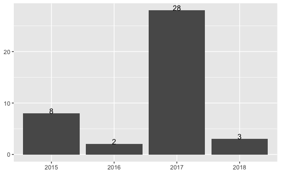

Petisi dengan judul yang mengandung term “go jek” pertama kali dibuat. Berdasarkan gambar di atas, petisi paling banyak dibuat pada tahun 2017? ada apakah pada tahun tersebut? apakah itu bertepatan dengan ekspansi gojek dan transportasi online lainnya ke daerah selain Jakarta? pertanyaan-pertnyaan tersebut akan berkaitan dengan **garis waktu keberadaan aplikasi transportasi online?** Sebagaimana diketahui bahwa petisi di sini pertama kali dibuat pada 2015-07-20 sementara aplikasi gojek pertama kali diluncurkan ke publik sekitar awal tahun 2015.

```
Skim summary statistics

Variable type: Date
           variable missing complete  n        min        max     median
 daftar_petisi$date       0       41 41 2015-07-20 2018-03-21 2017-07-24
 n_unique
       36
```

# 4 Apa isi komentar?

Untuk menjawab pertanyaan tersebut saya mencoba membedakan komentar petisi yang ditujukan untuk PT Gojek Indonesia (Gojek) dan untuk selainnya secara manual. Dengan kata lain, pembedaan dilakukan dengan mempertimbangkan deskripsi petisi dan yang dipetisi. Dengan pendekatan tersebut, terdapat satu petisi yang dianggap sesuai untuk dibedakan, yaitu petisi dengan judul “Perbaiki Sistem Gojek Yang Merugikan Driver” yang dibuat Adven Kris. Petisi komentar dari petisi ini selanjutnya disebut komentra “minus,” sementara yang lainnya disebut “plus.”

## 4.1 Isi komentar “plus”

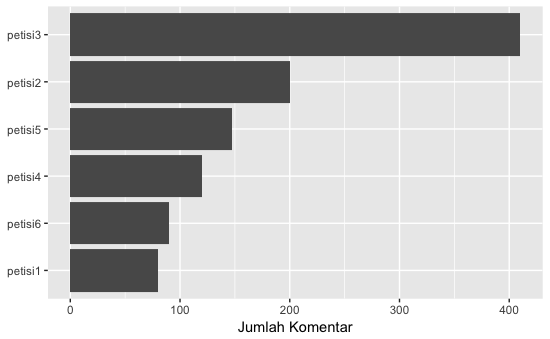

**Keterangan:**

1. petisi1 = Cabut larangan pengoperasian layanan transportasi berbasis online (Gojek, grabbike,dll)
2. petisi2 = Tolak Pencabutan gojek Tasikmalaya!
3. petisi3 = Jangan kembali renggut kebebasan masyarakat jawa barat untuk memilih transportasi!
4. petisi4 = Kami membutuhkan gojek
5. petisi5 = Dukung keberadaan gojek di purwokerto
6. petisi6 = Hentikan permenhub 108

Gambar di tas menunjukkan bahwa petisi yang paling banyak mendapat komentar adalah petisi terkait dengan “hak rakyat” untuk memilih jenis transportasi. Petisi ini dibuat atas nama “Warga Bandung.” Gambar berikut menunjukkan term-term utama dari komentar terhadap enam petisi di atas.

[figure not shown]

**Keterangan: Gambar menunjukkan TF-IDF (Term Frequency-Invers Document Metrics), di mana term dengan frekuensi tinggi dalam keselurhan dokumen memiliki nilai lebih rendah dibanding term yang dengan frekeunsi tinggi dalam sebuah dokumen dan tidak ada didokumen lain.**

Berdasarkan tf-idf term yang ditunjukkan oleh gambar di atas, diketahui bahwa seara umum petisi dibuat oleh masyarakat di daerah. Hal ini ditunjukkan dengan munculnya term seperti bandung (petisi3) dan purwokerto (petisi5), di mana di daerah tersebut terdapat kasus penolakan/pelarangan keberadaan transportasi online. Selain itu, secara umum juga dapat dilihat bahwa masyarakat merasa “membutuhkan” dan menilai transportasi online “membantu” kehidupan mereka, seperti diungkapkan oleh salah satu penandatangan dalam komentar berikut.

| Alasan | Nama |
| --- | --- |
| Kota mau maju kok dilarang. Sekarang sudah zaman teknologi, kenapa masih berpikiran seperti zaman PURBA. Dengan adanya Go-Jek itu sangat membantu. #savegojek | Warga Purwokerto |
| Gojek sangat membantu warga solo dalam kemudahan transportasi dan meningkatkan perekonomian para drivernya | Haryoseno Kuncoro |

**Keterangan: alasan diurutkan berdasarkan alasan yang mendapat “Likes” paling banyak**

Masyarakat merasa terbantu dengan keberadaan “Gojek” atau transportasi online karena beberapa alasan. Alasan tersebut diantaranya adalah mudah didapatkan, lebih nyaman dibanding transportasi publik yang sudah ada sebelumnya, dan lebih murah. Oleh karena itu, mereka (penandatangan “plus”) mempersepsikan Gojek sebagai “kebutuhan,” yang harus dipenuhi, dan melihat pemerintah tidak berhak melarang keberadaan transportasi online seperti yang disebutkan dalam komentar berikut.

| Alasan | Nama |
| --- | --- |
| Saya menandatangi ini karena saya sadar dengan semakin berkembangnya teknologi, hidup manusia seharusnya menjadi lebih gampang. Meniadakan dan melarang usaha kreatf dan mandiri sama sama saja dengan m… | Bayu Priyambodo |
| Transportasi murah, cepat dan nyaman adalah sudah menjadi kebutuhan. Jangan sembarangan melarang sesuatu yang menjadi hak kami pak.. | Nuril Dhanadiredja |

**Keterangan: alasan diurutkan berdasarkan alasan yang mendapat “Likes” paling banyak**

Berdasarkan persepsi itu pula penandatangan di sini berusaha membuat pemerintah (diwakili oleh presiden dan menteri) untuk membuat regulasi yang pada intinya menjamin terpenuhinya “hak” masyarakat untuk mendapatkan transportasi (yang membantu dan dibutuhkan mereka). Isu tentang transportasi online di sini dapat dianggap sebagai representasi ketidak berdayaan pemerintah mengimbangi akselerasi dan kreativitas teknologi. Karena itu pula beberapa point daru PERMENHUB 108 berikut ini ditolak.

1. Mobil harus mempunyai SRUT untuk uji kir
2. Mobil harus atas nama badan hukum kop/pt
3. Mobil wajib bersetiker untuk mrngetahui wilayah oprasinya( stiker dishub)
4. Driver Wajib memiliki Sim A umum

Dengan kata lain, di sini juga ada sudut pandang pemberi jasa (dalam kasus Gojek disebut mitra), yang melihat transportasi online sebagai sebuah lapangan pekerjaan.

## 4.2 Isi komentar “minus”

Kompleksitas isu seperti ditunjukkan oleh komentar-komentar penadatangan “plus” di atas tidak berhenti dengan petisi yang disebabkan adanya pelarang. Namun isu tentang transportasi online juga terkait dengan hak-hak mitra atau pemberi jasa transportasi online. Dalam konteks ini, salah satu petisi secara khusus ditujukan untuk perusahaan pembuat aplikasi transportasi online, yaitu PT Gojek Indonesia. Isi komentar petisi tersebut dapat dilihat pada gambar berikut.

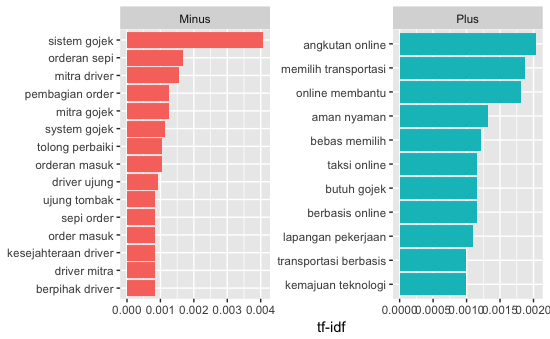

**Keterangan: Gambar menunjukkan tf-idf dengan membandingkan komentar dengan komentar yang sebelumnya “plus” untuk melihat keunikan term yang ada dalam komentar “minus”**

Sesuai dengan judulnya, isi komentar petisi “minus” tentang gojek berkaitan dengan sistem aplikasi. Dalam konteks ini, driver sebagai mitra menuntut PT Gojek Indonesia untuk memperbaiki sistem aplikasi agar tidak merugikan mereka. Hal yang dianggap merugikan di antaranya adalah: sistem dan tarif yang diterapkan. Hal tersebut diungkapkan dalam komentar berikut.

| Alasan | Nama |
| --- | --- |
| Saya merasa rugi kalo tarif gojek begitu2 az. Belom bensin, oli dll. Makan jg belom dihitung. Mohon pikir ulang ya bapak gojek | Zainal Arifin |
| Tolong severnye di cepet2 betulin klo erroe trus begini rugi jg nii klo prlu ganti IT nye jangan yg goblok di pake | Rahmat Basuki |

# 5 Pembahasan dan Simpulan

Berdasarkan waktunya, petisi-petisi yang dibuat di laman www.change.org yang terkait dengan kberadaan “transportasi online” cenderung mengikuti pola keberadaan aplikasi “transportasi online” di Indonesia. Hal ini dapat dilihat dari petisi yang pertama yang hanya berjarak enam bulan sejak aplikasi “Gojek” pertama kali diluncurkan. Jika laman petisis ini dianggap sebagai sebuah tempat publik, maka keberadaan aplikasi online dapat dikatakan memicu terungkapnya kebutuhan transportasi yang selama ini tidak disuarakan oleh publik. Dalam konteks ini, kebutuhan transportasi yang nyaman, aman, dan murah.

Transportasi online, dengan segala dinamikanya yang terjadi saat ini di persepsikan sebagai layanan yang memenuhi/mendekati syarat transportasi publik dalam benak masyarakat. Untuk itu, ketika ada ekspansi transportasi online yang ditolak, ketika ada regulasi dan aktor yang menghalangi, masyarakat bertindak atas nama “hak” bukan atas nama “transportasi online” atau “Gojek.”

Fenomena petisi tentang transportasi online, dengan alasan-alasan yang real membuat kita sadar dengan apa yang disebut oleh Supel (2010) sebagai kemayaan yang real. Dalam konteks ini, alasan-alasan para penandatanganan tidak dapat disentuh langsung atau terjadi secara virtual. Namun wacana yang melatarinya berisfat real dan dapat dirasakan oleh mereka. Sejalan dengan dengan Dahlgren (2015), hal ini merupakan cara baru dalam menjadi “masyarakat”. Dalam konteks yang sama Lim (2013) mengatakan *“the association is virtual, but the fight is real.”*